# D17129187_PSI_CA2

Orighomisan Omatsone

# 1. Introduction

This research investigates predicting the weight of an individual based on a set of variables

Now with multiple linear regression our new research question is **Can the weight of an individual be predicted given height, and age as our independent predictor variables and how much variance could be considered to be explained by the predictor variables. What difference does the addition of sex as a predictor do to the predictive power of our model.**

# 2. METHODOLOGY

This research will explore the relationship between our predictors and outcome variable in order to justify their inclusion as predictors.

Standardised scores for skewness and kurtosis ranging from +/-2 are considered acceptable in order to be categorised as a normal distribution (George & Mallery, 2010). As our dataset is more than 80, distributions are considered normal if 95% of the standardised scores fall between +/-3.29 (Field, Miles, & Field, 2012). While cases with missing data and outliers will be handled with the guidance of Andy Fields Discovering statistics using R.

For our tests, a p value lower than .05 is considered significant (Field, Miles, & Field, 2012).

In our handling of effect sizes, The guidance of Andy Fields Discovering statistics using R has been conuslted based on suggestions of Cohen (Field, Miles, & Field, 2012).

- r = .10 (small effect): In this case the effect explains 1% of the total variance.
- r = .30 (medium effect): The effect accounts for 9% of the total variance.
- r = .50 (large effect): The effect accounts for 25% of the variance.

According to Andy Fields, dn effect size is basically used to measure the impact of a difference in our research. Because it’s standardized it can be compared to various effect sizes from different researches and different variables (Field, Miles, & Field, 2012).

## 2.1 Variables of interest

The variables of interest used in this research are shown below:

```r
panderOptions('table.split.table', Inf)

my.data <- "
  Concept                       | Variable Name     | Statistical Type        | Possible Values
 Weight                          | weight           | Scale                   | Range from 43 to 160
 Height                         | height           | Scale                   | Range from 150 to 199
  Age                           | age               | Scale                   | Range from 18 to 84
  Sex                          | sex               | Nominal                 | 0=female; 1=male"

df <- read.delim(textConnection(my.data),header=FALSE,sep="|",strip.white=TRUE,stringsAsFactors=FALSE)
names(df) <- unname(as.list(df[1,])) # put headers on
df <- df[-1,] # remove first row
row.names(df)<-NULL
pander(df, style = 'rmarkdown')
```

| Concept | Variable Name | Statistical Type | Possible Values |
| --- | --- | --- | --- |
| Weight | weight | Scale | Range from 43 to 160 |
| Height | height | Scale | Range from 150 to 199 |
| Age | age | Scale | Range from 18 to 84 |
| Sex | sex | Nominal | 0=female; 1=male |

### 2.1.1 Dataset

Our data was gotten from respondents at a university who filled a survey.

## 2.2 Variable Inspection

```r
summary(sleepRegData)
```

```
##      weight           height           age            sex
##  Min.   : 43.00   Min.   :150.0   Min.   :18.00   Female:150
##  1st Qu.: 63.00   1st Qu.:162.5   1st Qu.:34.00   Male  :121
##  Median : 72.00   Median :170.0   Median :44.00
##  Mean   : 73.38   Mean   :170.2   Mean   :43.87
##  3rd Qu.: 82.00   3rd Qu.:178.0   3rd Qu.:54.00
##  Max.   :160.00   Max.   :199.0   Max.   :84.00
##  NA's   :22       NA's   :25      NA's   :23
```

```r
describe(sleepRegData[,-4])
```

```
##        vars   n   mean    sd median trimmed   mad min max range skew
## weight    1 249  73.38 15.28     72   72.58 14.83  43 160   117 1.00
## height    2 246 170.22 10.28    170  169.81 11.12 150 199    49 0.35
## age       3 248  43.87 12.68     44   43.80 14.83  18  84    66 0.07
##        kurtosis   se
## weight     3.33 0.97
## height    -0.64 0.66
## age       -0.60 0.81
```

### 2.2.1 Weight

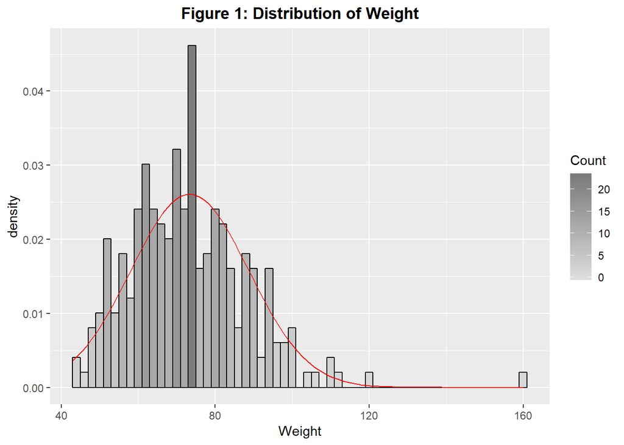

```r
# histogram weight
theme_update(plot.title = element_text(hjust = 0.5, face="bold"))
gg <- ggplot(sleepRegData, aes(x=weight)) + labs(x="Weight") +
        geom_histogram(binwidth=2, colour="black", aes(y=..density.., fill=..count..)) +
        scale_fill_gradient("Count", low="#DCDCDC", high="#7C7C7C") +
        stat_function(fun=dnorm, color="red",args=list(mean=mean(sleepRegData$weight, na.rm=TRUE), sd=sd(sleepRegData$weight, na.rm=TRUE))) +
        ggtitle('Figure 1: Distribution of Weight')

gg
```

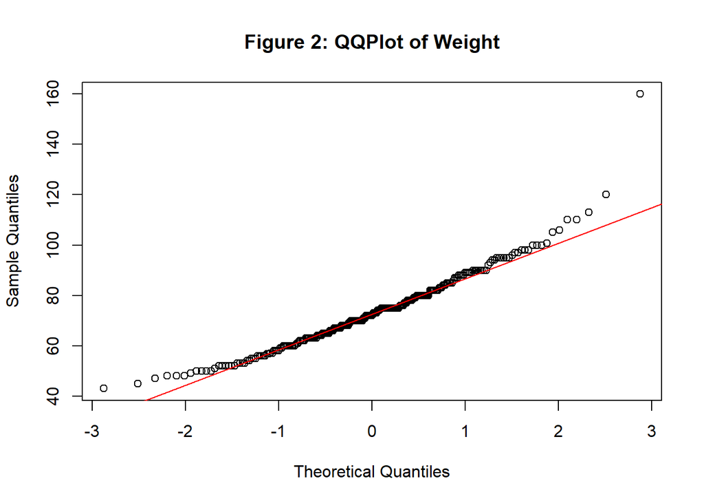

```r
#qqplot for weight
qqnorm(sleepRegData$weight, main="Figure 2: QQPlot of Weight")
qqline(sleepRegData$weight, col=2) #show a line on theplot
```

```r
#skewness and kurtosis from semTools with standard error
tpskew<-skew(sleepRegData$weight)
tpkurt<-kurtosis(sleepRegData$weight)
#We divide the skew statistic by the standard error to get the standardised score
stdskew<-tpskew[1]/tpskew[2]
stdkurt<-tpkurt[1]/tpkurt[2]

# standardised skew for weight
stdskew
```

```
## skew (g1)
##  6.498358
```

```r
# standardised kurtosis for weight
stdkurt
```

```
## Excess Kur (g2)
##        11.18265
```

```r
#Use dplyr filter to filter out the rows with a standardised value outsude the range
outliers <- sleepRegData %>%
  filter(scale(weight) >3.29 | scale(weight) < -3.29)

#count them using dplyr summarize
numoutliers<-outliers %>% summarize(count=n())
fullcount<-sleepRegData %>% summarize(count=n())

round((numoutliers/fullcount)*100, digits=2)
```

```
##   count
## 1  0.37
```

### 2.2.2 Height (height)

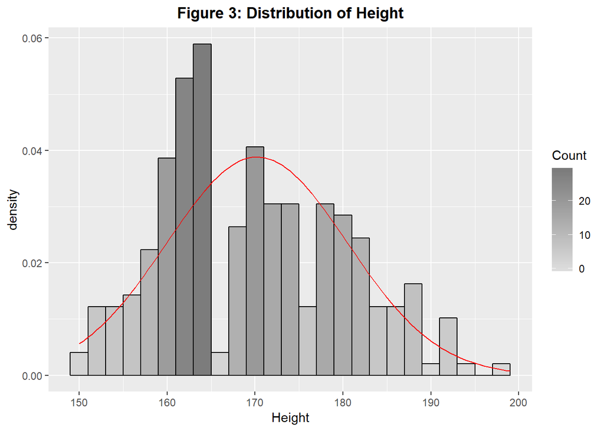

```r
# histogram height
theme_update(plot.title = element_text(hjust = 0.5, face="bold"))
gg <- ggplot(sleepRegData, aes(x=height)) + labs(x="Height") +
        geom_histogram(binwidth=2, colour="black", aes(y=..density.., fill=..count..)) +
        scale_fill_gradient("Count", low="#DCDCDC", high="#7C7C7C") +
        stat_function(fun=dnorm, color="red",args=list(mean=mean(sleepRegData$height, na.rm=TRUE), sd=sd(sleepRegData$height, na.rm=TRUE))) +
        ggtitle('Figure 3: Distribution of Height')

gg
```

[figure not shown]

```r
#qqplot for height
qqnorm(sleepRegData$height, main="Figure 4: QQPlot of Stress Levels")
qqline(sleepRegData$height, col=2) #show a line on theplot
```

```r
#skewness and kurtosis for height variable from semTools with standard error
tpskew<-skew(sleepRegData$height)
tpkurt<-kurtosis(sleepRegData$height)
#We divide the skew statistic by the standard error to get the standardised score
stdskew<-tpskew[1]/tpskew[2]
stdkurt<-tpkurt[1]/tpkurt[2]

#standardised skewness for height
stdskew
```

```
## skew (g1)
##  2.274914
```

```r
#standardised kurtosis for height
stdkurt
```

```
## Excess Kur (g2)
##       -1.954019
```

```r
#Use dplyr filter to filter out the rows with a standardised value outsude the range
outliers <- sleepRegData %>%
  filter(scale(height) >3.29 | scale(height) < -3.29)

#count them using dplyr summarize
numoutliers<-outliers %>% summarize(count=n())
fullcount<-sleepRegData %>% summarize(count=n())

# % outside range
round((numoutliers/fullcount)*100, digits=2)
```

```
##   count
## 1     0
```

### 2.2.3 Age (age)

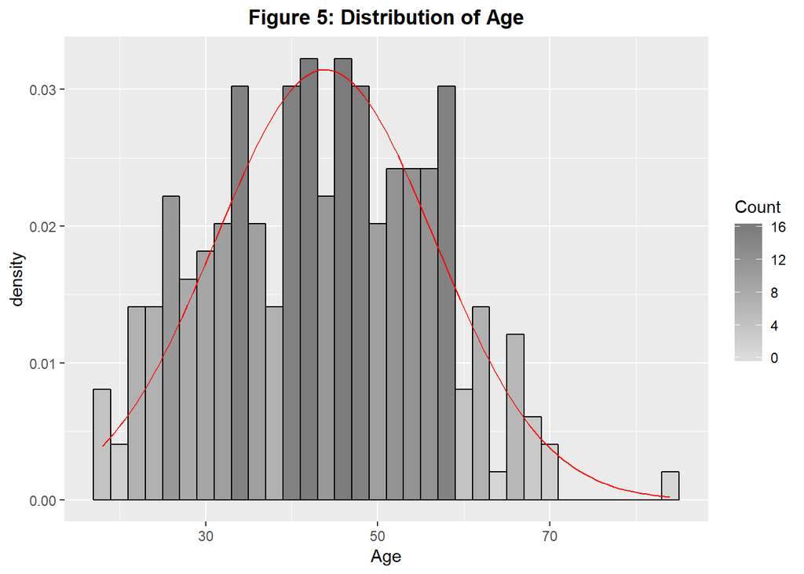

```r
theme_update(plot.title = element_text(hjust = 0.5, face="bold"))
gg <- ggplot(sleepRegData, aes(x=age)) + labs(x="Age") +
        geom_histogram(binwidth=2, colour="black", aes(y=..density.., fill=..count..)) +
        scale_fill_gradient("Count", low="#DCDCDC", high="#7C7C7C") +
        stat_function(fun=dnorm, color="red",args=list(mean=mean(sleepRegData$age, na.rm=TRUE), sd=sd(sleepRegData$age, na.rm=TRUE))) +
        ggtitle('Figure 5: Distribution of Age')

gg
```

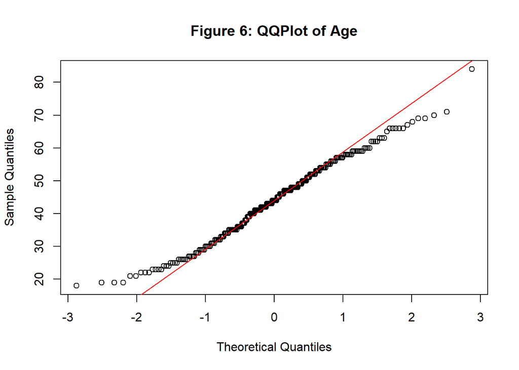

```r
#qqplot for age
qqnorm(sleepRegData$age, main="Figure 6: QQPlot of Age")
qqline(sleepRegData$age, col=2) #show a line on theplot
```

```r
#skewness and kurtosis from semTools with standard error
tpskew<-skew(sleepRegData$age)
tpkurt<-kurtosis(sleepRegData$age)
#We divide the skew statistic by the standard error to get the standardised score
stdskew<-tpskew[1]/tpskew[2]
stdkurt<-tpkurt[1]/tpkurt[2]

# standardised skewness
stdskew
```

```
## skew (g1)
## 0.4800141
```

```r
# standardised kurtosis
stdkurt
```

```
## Excess Kur (g2)
##       -1.819329
```

```r
#Use dplyr filter to filter out the rows with a standardised value outsude the range
outliers <- sleepRegData %>%
  filter(scale(age) >3.29 | scale(age) < -3.29)

#count them using dplyr summarize
numoutliers<-outliers %>% summarize(count=n())
fullcount<-sleepRegData %>% summarize(count=n())

# % outside range
round((numoutliers/fullcount)*100, digits=2)
```

```
##   count
## 1     0
```

### 2.2.5 Report of normality analysis

```r
panderOptions('table.split.table', Inf)

my.data <- "
Variable  |  Mean   |  std Skewness           |  std Kurtosis           |  Std Deviation  | % std scores of Outside +-3.29  | No. of Cases
weight    |  73.38  |  6.50                   |  11.18                  |  15.28          |  .37                            |  249
height    |  170.22 |  2.27                   |  -1.95                  |  10.28          |  0                              |  246
age       |  43.87  |  0.48                   |  -1.82                  |  12.68          |  0                              |  248
depress   |  3.50   |  6.37                   |  0.36                   |  2.99           |  0                              |  269
"

df <- read.delim(textConnection(my.data),header=FALSE,sep="|",strip.white=TRUE,stringsAsFactors=FALSE)
names(df) <- unname(as.list(df[1,])) # put headers on
df <- df[-1,] # remove first row
row.names(df)<-NULL
pander(df, style = 'rmarkdown')
```

| Variable | Mean | std Skewness | std Kurtosis | Std Deviation | % std scores of Outside +-3.29 | No. of Cases |
| --- | --- | --- | --- | --- | --- | --- |
| weight | 73.38 | 6.50 | 11.18 | 15.28 | .37 | 249 |
| height | 170.22 | 2.27 | -1.95 | 10.28 | 0 | 246 |
| age | 43.87 | 0.48 | -1.82 | 12.68 | 0 | 248 |
| depress | 3.50 | 6.37 | 0.36 | 2.99 | 0 | 269 |

Inspection of standardized normal scores for skewness and kurtosis indicated that age is within the acceptable range of +/-2 and will be considered normal. Height is very close the acceptable range of +/-2 in terms of skewness but marginally passes it. However, given that 100% of the standardised scores fall within +-3.29, it will be considereded as approaching normality. Weights kurtosis and skewness do not fall withing the acceptablerange of +-2, however, only 1 of it’s values (0.37%) falls outside the acceptable range of +-3.29 and will be considered normal.

For the outlier which occurs in weight, given that this value does not seem to be an error as we are unable to prove it, we will leave it in our dataset but acknowledge it’s existence.

Hence, our continous variables will be considered approaching normality for this experiment.

### 2.2.6 Sex (sex)

Sex is represented by a categorical variable in the dataset. The dataset contains data from 150 female respondents and 121 male respondents.

At June 2017, there were 193,900 more females than males residing in Australia, with 12.2 million males and 12.4 million females.(Australian Bureau of Statistics, 2018).

So we believe our data gives us a fair representativeness of both genders.

```r
table(sleepRegData$sex)
```

```
##
## Female   Male
##    150    121
```

```r
#Get descriptive stastitics by group
describeBy(sleepRegData$weight, sleepRegData$sex)
```

```
##
##  Descriptive statistics by group
## group: Female
##    vars   n  mean    sd median trimmed   mad min max range skew kurtosis
## X1    1 138 66.09 12.25     65   65.06 10.38  43 106    63 0.86     0.88
##      se
## X1 1.04
## --------------------------------------------------------
## group: Male
##    vars   n  mean    sd median trimmed   mad min max range skew kurtosis
## X1    1 111 82.45 13.78     80   81.49 10.38  54 160   106 1.79     7.85
##      se
## X1 1.31
```

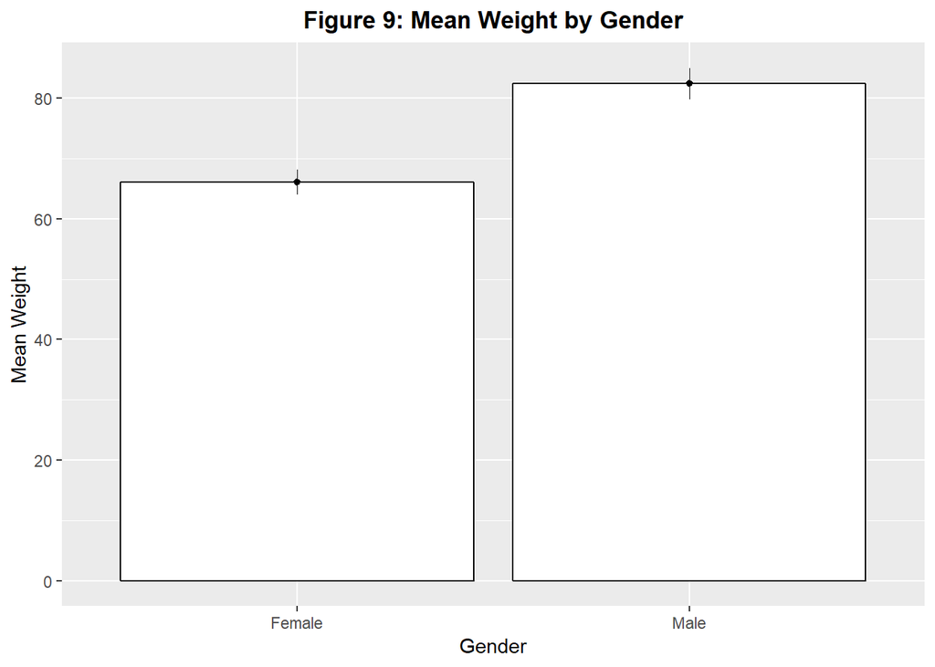

```r
genderPlot <- ggplot(sleepRegData, aes(sex,weight)) +
              stat_summary(fun.y = mean, geom = 'bar', color='black',fill='white') +
              stat_summary(fun.data = mean_cl_normal, geom = 'pointrange', size=0.2) +
              labs(x='Gender',y='Mean Weight',title="Figure 9: Mean Weight by Gender")
genderPlot
```

### 2.2.7 Report of Gender weight

From figure 9 and our descriptive stat, we notice that males have a greater Weight than their female counterpart. We observed higher mean and median levels in males (mean =82.45, median=80, n=111) compared to females (mean=66.09,median=65, n=138)

### 2.2.8 Cases and Missing Values

For this research, cases wth missing values were Ignored.

## 2.3 Previous statistical tests

As our data has met the assumption of normality and we have established a significant relationship between our predictors and outcome variable. There is enough evidence to support their inclusion as predictors into our regression models.

### 2.3.1 Correlation

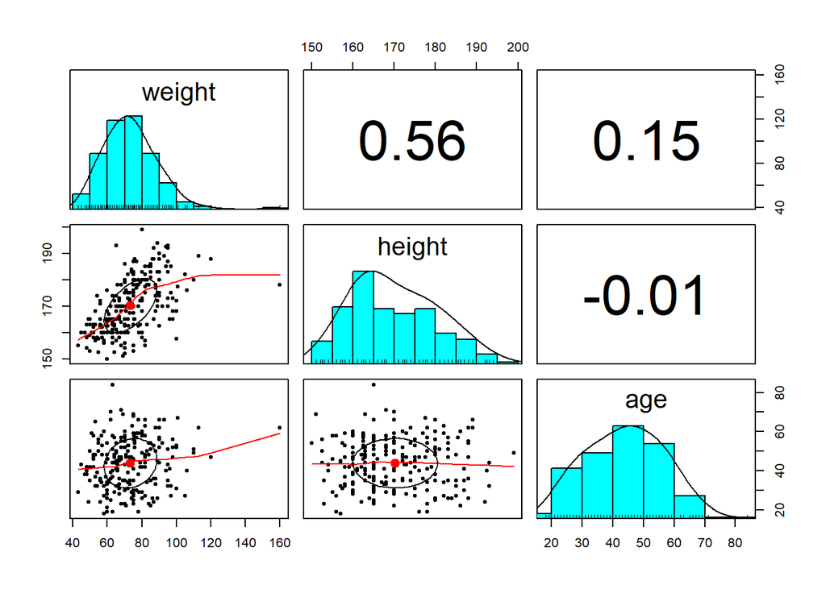

```r
# Pairs Panels showing histogram and density curve of variables and scatter plot and pearson correlation between them
pairs.panels(sleepRegData[,-4])
```

From the Pearson Correlation on the Pairs Panel plot and the correlation tests below, we observe;

```r
cor.test(sleepRegData$weight, sleepRegData$height)
```

```
##
##  Pearson's product-moment correlation
##
## data:  sleepRegData$weight and sleepRegData$height
## t = 10.512, df = 239, p-value < 2.2e-16
## alternative hypothesis: true correlation is not equal to 0
## 95 percent confidence interval:
##  0.4692465 0.6429549
## sample estimates:
##       cor
## 0.5622719
```

The covariance is another measure of the relationship between the two vairables. It shows how changes in one variable affect the other variable.

Our covariance for weight and height is 88.73

```r
cor.test(sleepRegData$weight, sleepRegData$age)
```

```
##
##  Pearson's product-moment correlation
##
## data:  sleepRegData$weight and sleepRegData$age
## t = 2.2814, df = 224, p-value = 0.02346
## alternative hypothesis: true correlation is not equal to 0
## 95 percent confidence interval:
##  0.02059752 0.27577013
## sample estimates:
##       cor
## 0.1506929
```

Our covariance for weight and age is 29.79

```r
cor.test(sleepRegData$age, sleepRegData$height)
```

```
##
##  Pearson's product-moment correlation
##
## data:  sleepRegData$age and sleepRegData$height
## t = -0.14308, df = 222, p-value = 0.8864
## alternative hypothesis: true correlation is not equal to 0
## 95 percent confidence interval:
##  -0.1405085  0.1216334
## sample estimates:
##          cor
## -0.009602533
```

### 2.3.2 Difference

We check if our data has violated the homegeinity rule with levenes test.

```r
leveneTest(sleepRegData$weight,sleepRegData$sex, median)
```

```
## Levene's Test for Homogeneity of Variance (center = median)
##        Df F value Pr(>F)
## group   1  0.2111 0.6463
##       247
```

From the test, we can see that homogeinity has not been violated in our data p > .05

We run our t test

```r
genderTest <- t.test(weight ~ sex, data = sleepRegData)
genderTest
```

```
##
##  Welch Two Sample t-test
##
## data:  weight by sex
## t = -9.7814, df = 222.22, p-value < 2.2e-16
## alternative hypothesis: true difference in means is not equal to 0
## 95 percent confidence interval:
##  -19.66139 -13.06738
## sample estimates:
## mean in group Female   mean in group Male
##             66.08877             82.45315
```

Calculate the effect size.

```r
genderTest_t <- genderTest$statistic[[1]]
genderTest_df <- genderTest$parameter[[1]]
genderTest_r <- sqrt(genderTest_t^2/(genderTest_t^2+genderTest_df))
genderTest_r
```

```
## [1] 0.5486031
```

A Levene’s test for homogeneity of variance was conducted and indicated equality of variance for Weight for male and female respondents (F(1,247) =0.21, P=.64).

An independent-samples t-test was conducted to compare Weight for male and female respondents. A significant difference was found (m=66.0887681, sd=12.2529291) for female respondents, (m=82.4531532, sd=13.7813762) for male respondents with (t(222)= -9.78, p < .05).

# 3 Regression

We intend to build to multiple regression models to predict weight, using height, age and sex as predictors.

Missing data will not be imputed, they will be left out of the model. For the reason that replacing the missing data is from a variety if respondents with varying features. imputing them will affect our model so ignoring them when we build our models will be better as we still have a relatively large sample dataset in terms of this project.

In the case of outliers, we will not remove them completely. Outliers will be acknowledged, and the bias they introduce will also be acknowledged. However, the model will be done again without the outliers to compare the effect of removing the outlier from the model and leaving the outlier in the model. This will be done for every model in this research.

Our first (baseline) model will be a model using only height and age as predictors.

Our second model will add sex as a predictor to see the difference in predicting power tha occurs when adding a nominal variable of sex.

Our data would be randomised and divided into two. 70% for the training data set to train our model and the remaining 30% into the test data set ot test our model.

```r
sleepRegDataM <- sleepRegData
set.seed(2)
rows <- sample(nrow(sleepRegDataM))
sleepRegDataM <- sleepRegDataM[rows, ]

split <- round(nrow(sleepRegDataM) * .70)
training_data <- sleepRegDataM[1:split, ]

test_data <- sleepRegDataM[(split + 1):nrow(sleepRegDataM), ]
```

## 3.1 Base Model

Null Hypothesis: There will be no significant prediction of weight by height, and age.

We create a regression model to predict weight from height, and age.

**train model**

```r
base_model <- lm(weight ~ height + age, data = training_data)
summary(base_model)
```

```
##
## Call:
## lm(formula = weight ~ height + age, data = training_data)
##
## Residuals:
##     Min      1Q  Median      3Q     Max
## -27.676  -8.120  -1.034   6.003  75.322
##
## Coefficients:
##              Estimate Std. Error t value Pr(>|t|)
## (Intercept) -74.13831   17.68583  -4.192 4.63e-05 ***
## height        0.81146    0.10337   7.850 6.41e-13 ***
## age           0.23189    0.08781   2.641  0.00912 **
## ---
## Signif. codes:  0 '***' 0.001 '**' 0.01 '*' 0.05 '.' 0.1 ' ' 1
##
## Residual standard error: 13.16 on 155 degrees of freedom
##   (32 observations deleted due to missingness)
## Multiple R-squared:  0.3186, Adjusted R-squared:  0.3098
## F-statistic: 36.24 on 2 and 155 DF,  p-value: 1.222e-13
```

```r
lm.beta(base_model)
```

```
##    height       age
## 0.5222160 0.1756817
```

**test model**

```r
test_base_model <- predict(base_model, test_data)
difference <-   test_data$weight - test_base_model

# Calculate RMSE
sqrt(mean(difference^2, na.rm = T))
```

```
## [1] 11.85684
```

From our model summary;

**height**

our height estimate gives us the slope. A 1 unit increase in height changes the Weight by .81

The t value gives us how big the estimate is relative to the std. error it is 7.85.

**age**

our age estimate gives us the slope. for a 1 unit increase in Age changes the Weight by .23.

The estimate in variability std error for age is .087.

The t value gives us how big the estimate is relative to the std. error it is 2.64

Pr(>|t|) tells us our age predictor is statistically significant at p < .05.

**Residual Standard Error**

This is the average error in our model (13.16), how well it predicts Weight.

Hence, from our base model regression we estimate an error rate of 17.76%

**R-Squared**

Our R-Squared value means our predictor variables account for 31.86% of the variation of Weight (R-Squared 0.3186; Adjusted R-Squared 0.3098).

Our R-Squared and Adjusted R-Squared are very similar indicating good cross validity of our model.

**F-Statistic**

Measures the overall significance of our model.

Based on our data, a significant regression model was found at F(2,155) = 36.24, p < 0.05.

Hence we can say our model is significantly better than not having a model. **We Reject the Null Hypothesis**

From our prediction;

**Root Mean Square Error**

The standard deviation of the prediction error. 11.8568359

**Outliers**

```r
bm_df <- as.data.frame(base_model$residuals)
names(bm_df) <- 'residuals'
base_model_outliers <- bm_df %>%
  filter(scale(residuals) >3.29 | scale(residuals) < -3.29)

#count them using dplyr summarize
num_base_model_outliers<-base_model_outliers %>% summarize(count=n())
fullcount_base_model<-bm_df %>% summarize(count=n())

# % outside range
round((num_base_model_outliers/fullcount_base_model)*100, digits=2)
```

```
##   count
## 1  0.63
```

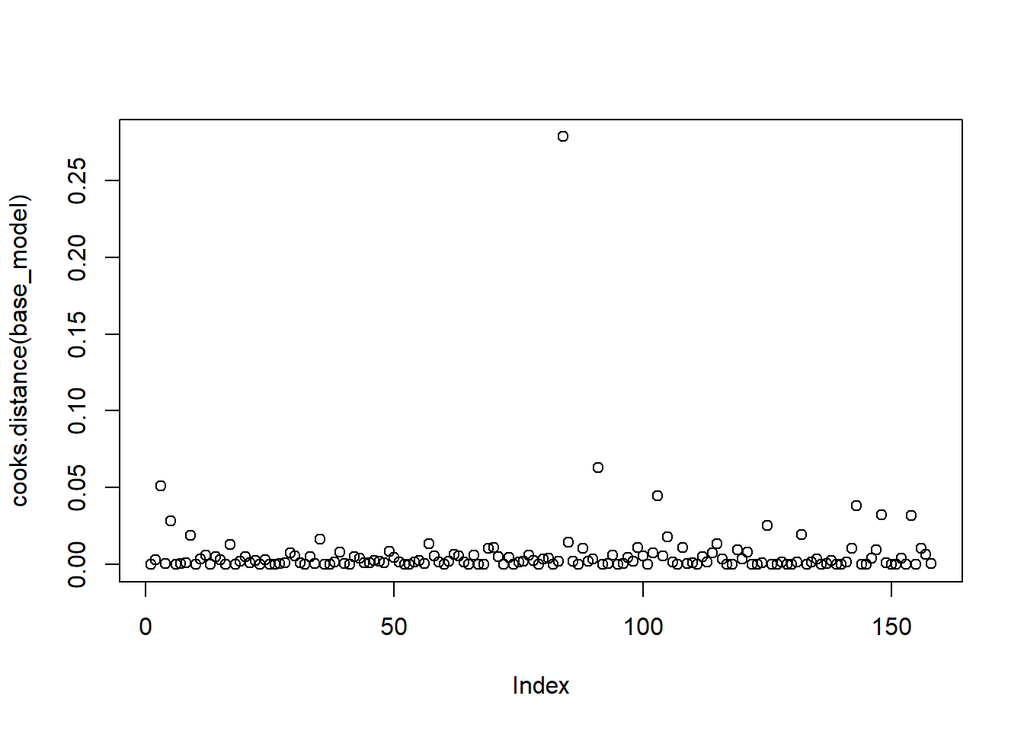

```r
plot(cooks.distance(base_model))
```

```r
max(cooks.distance(base_model))
```

```
## [1] 0.2784813
```

Analysis of the standardised residuals showed 0.63%, (1 case(s)) of residuals outside the limits of +/-3.29.

Analysis of cooks distance showed the outlier, but however also showed no value greater than 1.

We therefore acknowledge this outlier and the bias it potentially introduces to our model.

**Diagnostic Plots**

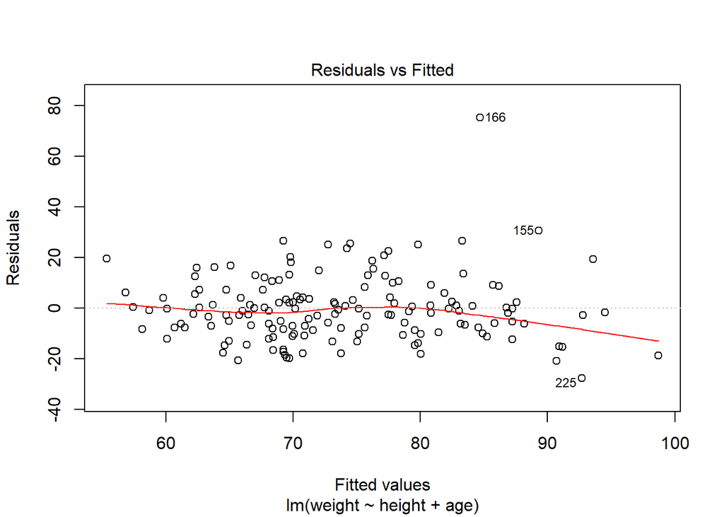

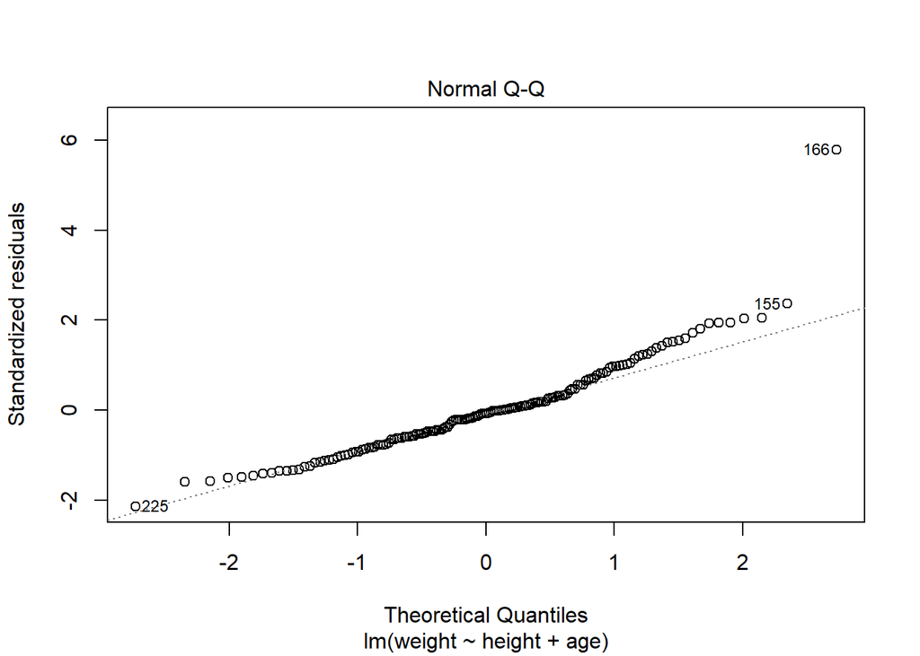

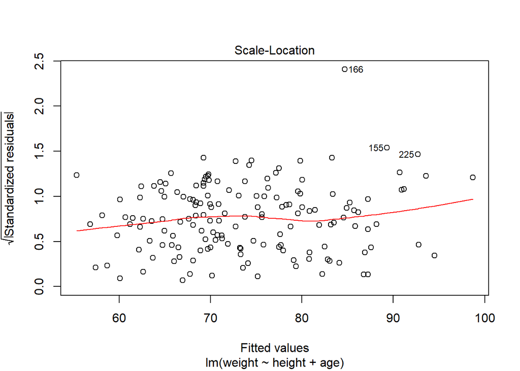

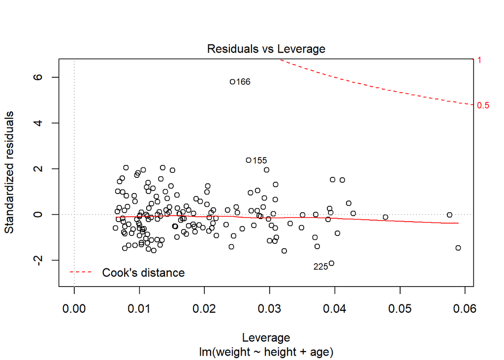

```r
plot(base_model)
```

The residual vs fitted plot gives us the predicted values on the x asis and residuals on the Y.

The red line shows us the linearity assumption has been met as it is fairly flat.

Our points are in a constant pattern that show us variation is contstant.

The normal Q-Q Plot, the y axis is the ordered observed standardized residuals while the x axis is the ordered theoretical residuals. This is what we expect the residuals to be if the errors are normally distributed.

We see from the Q-Q plot our our residuals aare roughly normally distributed as the fall along the diagonal line.

From the scale-location plot we can see the assumption of equal variance has been met.

The residual vs leverage plot shows us no influential cases as all our points are within the dashed cooks distance line. We do however notice a point (our earlier indentified outlier in our variable inspection) close but still within the line.

We will analyse the standardised residuals

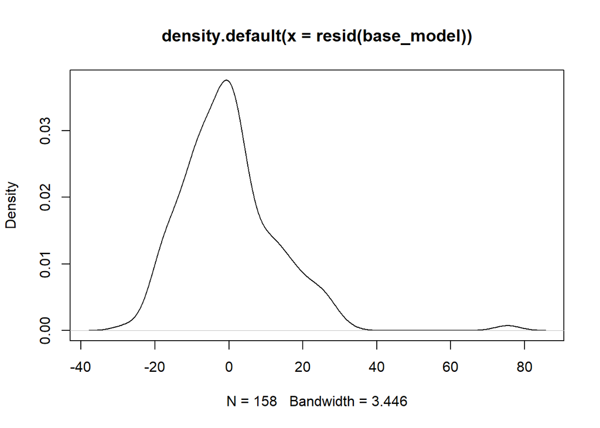

```r
plot(density(resid(base_model)))
```

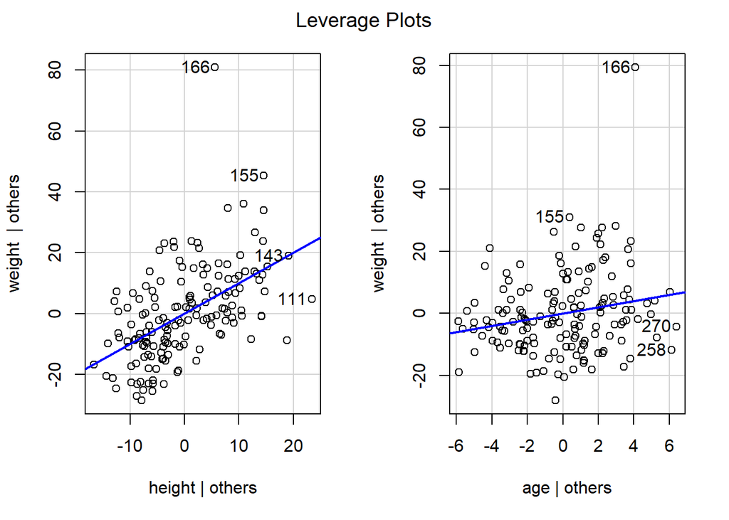

```r
leveragePlots(base_model)
```

The density plot of the residuals also shows the residuals are roughly normally distributed, however, the outlier slightly distorts this.

```r
# vif
vif(base_model)
```

```
##   height      age
## 1.006783 1.006783
```

```r
#tolerance
1/vif(base_model)
```

```
##   height      age
## 0.993263 0.993263
```

Our Vif values are below 10 and our tolerance 1/vif are above 0.1 indicating no multicolinearity in our model. This simply means our predictors are not highly correlated to each other.

### 3.1.1 Base Model Interpretation

A multiple regression analysis was conducted to determine if an individuals height and Age could predict an individuals weight.

A coefficient shows the change in our outcome variable given a unit of change in a predictor variable. we add these coefficients and the intercept to predict our outcome.

The values for the coefficients give us the coefficient values for our linear equation.

From the model, our equation is;

```
weight = -74.138 + 0.811(height) + 0.232(age)
```

Using the mean height and age as example;

```
-74.138 + 0.811 * (170.22) + 0.232 * (43.87) = 74.09
```

Analysis of cooks distance showed no undue influence.

However, as a result of the outlier, we do notice it’s effect on our plots. However, in a later section we will still analyse and compare our model without this outlier

Examination for multicollinearity showed that the tolerance and variance influence factor measures where within acceptable levels (vif < 10; tolerance > 0.1) as outlined in (Field, Miles, & Field, 2012).

We however use the RMSE to show the standard deviation of our prediction error. The RMSE for our base model with the outlier is 11.86

*Our regression model allows us to reject the null hypothesis that there will be no significant prediction of weight by height and age*

## 3.2 Second Model

Null Hypothesis: There will be no significant prediction of weight by height, Age and sex

We add sex to our regression model to test for a difference in prediction power.

**train model**

```r
sex_model <- lm(weight ~ height + age + sex, data = training_data)
summary(sex_model)
```

```
##
## Call:
## lm(formula = weight ~ height + age + sex, data = training_data)
##
## Residuals:
##     Min      1Q  Median      3Q     Max
## -23.670  -8.003  -1.771   6.171  72.521
##
## Coefficients:
##              Estimate Std. Error t value Pr(>|t|)
## (Intercept) -16.00983   23.28142  -0.688 0.492698
## height        0.44546    0.14107   3.158 0.001914 **
## age           0.21938    0.08457   2.594 0.010398 *
## sexMale      10.59555    2.89578   3.659 0.000347 ***
## ---
## Signif. codes:  0 '***' 0.001 '**' 0.01 '*' 0.05 '.' 0.1 ' ' 1
##
## Residual standard error: 12.66 on 154 degrees of freedom
##   (32 observations deleted due to missingness)
## Multiple R-squared:  0.3731, Adjusted R-squared:  0.3609
## F-statistic: 30.56 on 3 and 154 DF,  p-value: 1.482e-15
```

```r
lm.beta(sex_model)
```

```
##    height       age   sexMale
## 0.2866763 0.1662058 0.3323130
```

**test model**

```r
test_sex_model <- predict(sex_model, test_data)
difference <-   test_data$weight - test_sex_model

# Calculate RMSE
sqrt(mean(difference^2, na.rm = T))
```

```
## [1] 11.83663
```

From our model summary;

**height**

our height estimate gives us the slope. A 1 unit increase in height changes the Weight by .44

The estimate in variability std error for depression is .141.

The t value gives us how big the estimate is relative to the std. error it is 3.16.

Pr(>|t|) tells us our depression predictor is statistically significant at p < .05.

**age**

our age estimate gives us the slope. for a 1 unit increase in Age changes the Weight by .219.

The estimate in variability std error for age is .085.

The t value gives us how big the estimate is relative to the std. error it is 2.59

Pr(>|t|) tells us our age predictor is statistically significant at p < .05.

**sex**

The estimate in variability std error for depression is 2.896.

The t value gives us how big the estimate is relative to the std. error it is 3.66.

Pr(>|t|) tells us our sex predictor is statistically significant at p < .001.

**Residual Standard Error**

Hence, from our sex model regression we estimate an error rate of 17.09%

**R-Squared**

Our R-Squared value means our predictor variables account for 37.31% of the variation of Weight (R-Squared 0.3731; Adjusted R-Squared 0.3609).

Our R-Squared and Adjusted R-Squared are very similar indicating good cross validity of our model.

**F-Statistic**

Measures the overall significance of our model.

Based on our data, a significant regression model was found at F(3,154) = 30.56, p < 0.05.

Hence we can say our model is significantly better than not having a model. **We Reject the Null Hypothesis**

From our model prediction;

**Root Mean Square Error**

The standard deviation of the prediction error. 11.8366281

**Outliers**

```r
sm_df <- as.data.frame(sex_model$residuals)
names(sm_df) <- 'residuals'
sex_model_outliers <- bm_df %>%
  filter(scale(residuals) >3.29 | scale(residuals) < -3.29)

#count them using dplyr summarize
num_sex_model_outliers<-sex_model_outliers %>% summarize(count=n())
fullcount_sex_model<-bm_df %>% summarize(count=n())

# % outside range
round((num_sex_model_outliers/fullcount_sex_model)*100, digits=2)
```

```
##   count
## 1  0.63
```

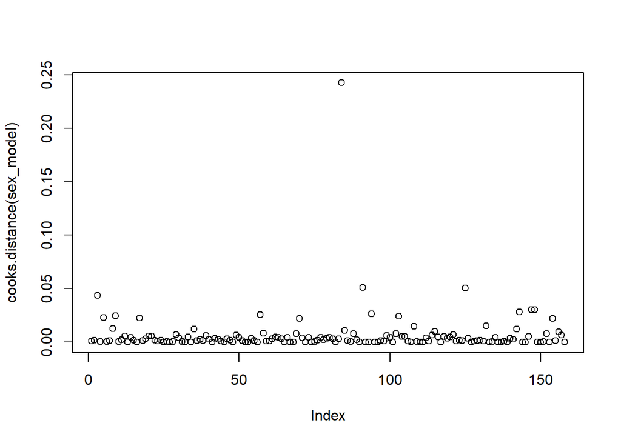

```r
plot(cooks.distance(sex_model))
```

```r
max(cooks.distance(sex_model))
```

```
## [1] 0.2424018
```

Analysis of the standardised residuals showed 0.63%, (1 case(s)) of residuals outside the limits of +/-3.29.

Analysis of cooks distance showed the outlier, but however also showed no value greater than 1.

We therefore acknowledge this outlier and the bias and influence it introduces to our model. However, given the influence still falls within the acceptable value we will not remove it.

**Diagnostic Plots**

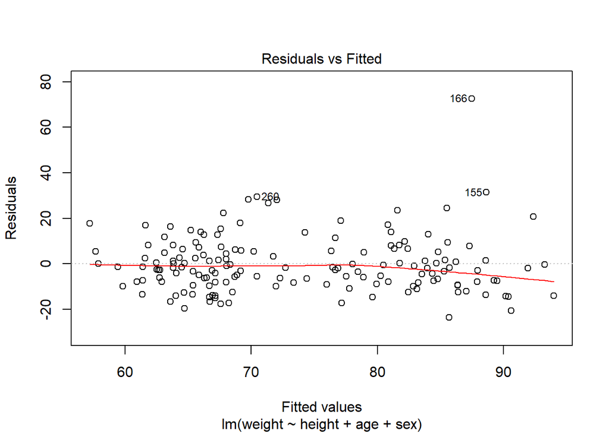

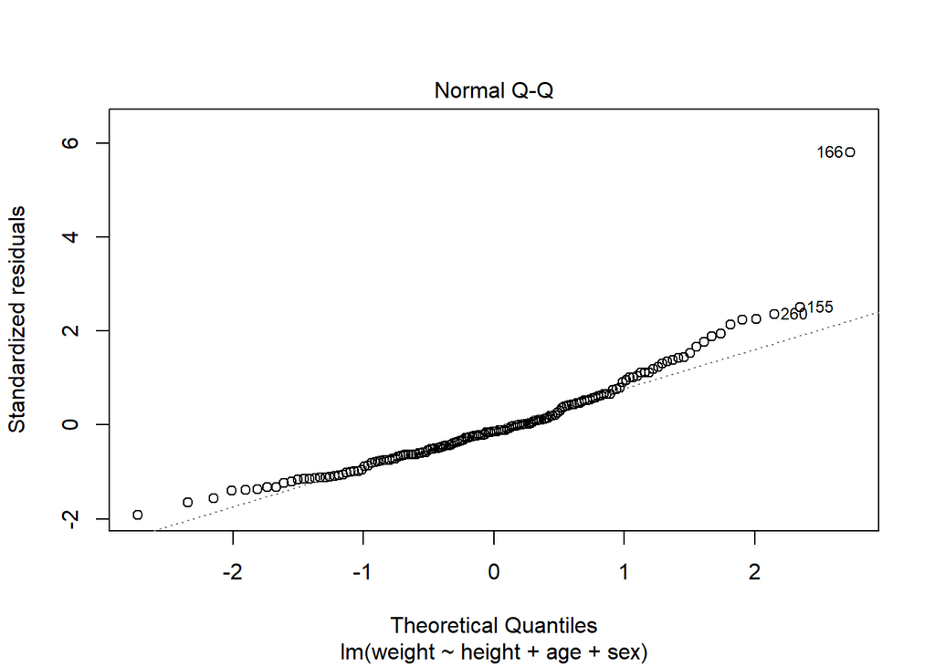

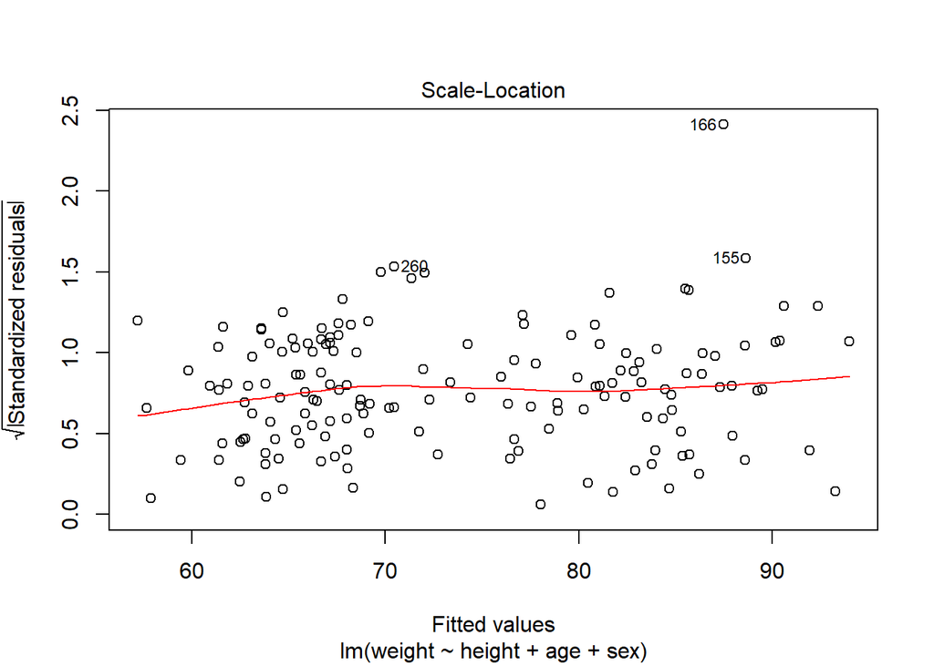

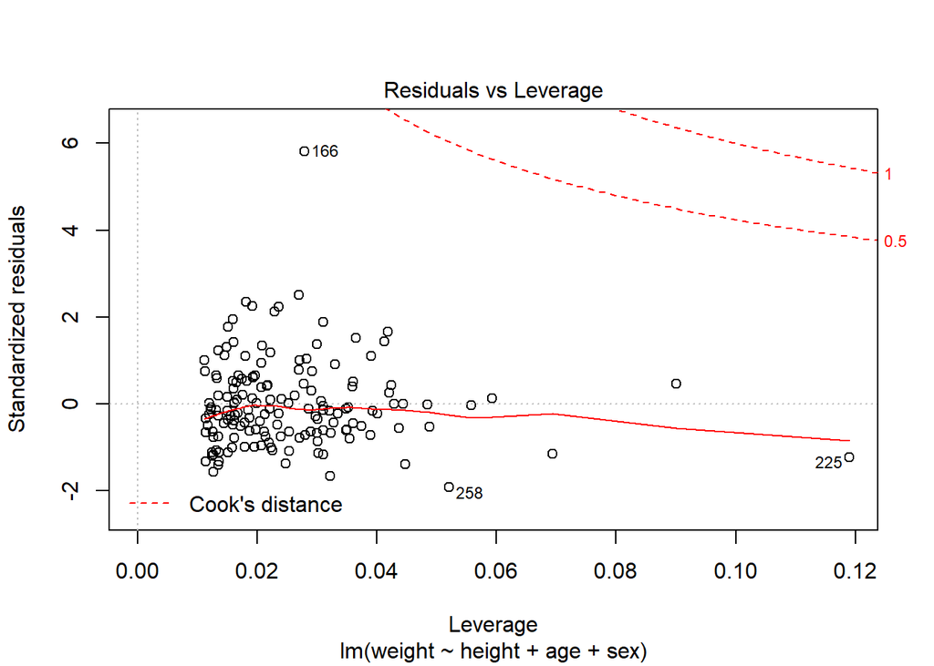

```r
plot(sex_model)
```

The residual vs fitted plot gives us the predicted values on the x asis and residuals on the Y.

The red line shows us the linearity assumption has been met as it is fairly flat.

Our points are in a constant pattern that show us variation is contstant.

The normal Q-Q Plot, the y axis is the ordered observed standardized residuals while the x axis is the ordered theoretical residuals. This is what we expect the residuals to be if the errors are normally distributed.

We see from the Q-Q plot our our residuals aare roughly normally distributed as the fall along the diagonal line.

From the scale-location plot we can see the assumption of equal variance has been met.

The residual vs leverage plot shows us no influential cases as all our points are within the dashed cooks distance line. We do however notice a point (our earlier indentified outlier in our variable inspection) close but still within the line.

We will analyse the standardised residuals

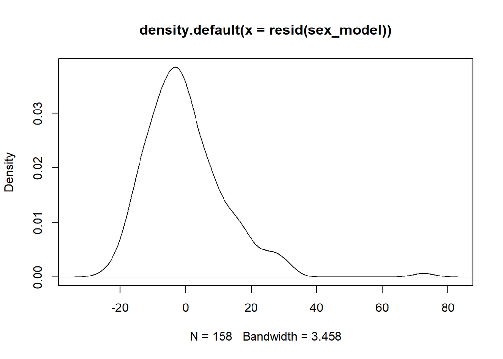

```r
plot(density(resid(sex_model)))
```

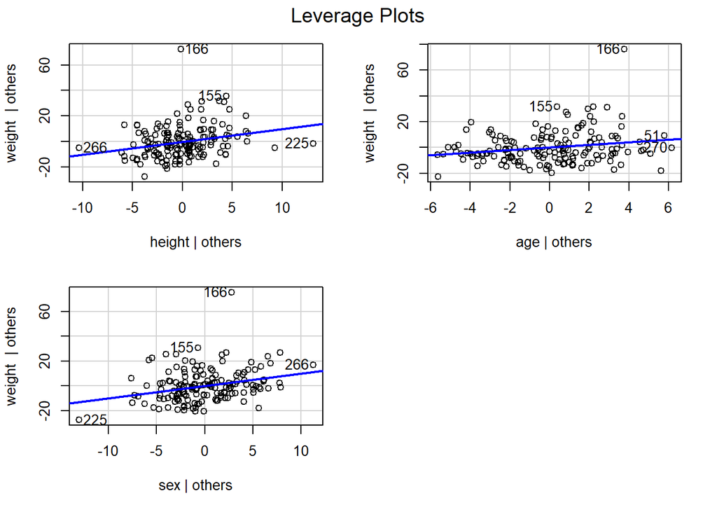

```r
leveragePlots(sex_model)
```

The density plot of the residuals also shows the residuals are roughly normally distributed, however, the outlier slightly distorts this.

```r
# vif
vif(sex_model)
```

```
##   height      age      sex
## 2.024805 1.008430 2.026393
```

```r
#tolerance
1/vif(sex_model)
```

```
##    height       age       sex
## 0.4938748 0.9916402 0.4934877
```

Our Vif values are below 10 and our tolerance 1/vif are above 0.1 indicating no multicolinearity in our model. This simply means our predictors are not highly correlated to each other.

### 3.2.1 Sex Model Interpretation

A multiple regression analysis was conducted to determine if an individuals height, Age and the added difference of sex could predict an individuals weight.

A significant regression model was found (F(3,154)= 30.56, p<.05) with the predictors being able to explain approx. 37% of the variation in weight. As the multiple R-Squared was .373 and adjusted R-Squared of .361. The similarity in both the multiple and adjusted R-Squared indicated good cross validity of our model.

A coefficient shows the change in our outcome variable given a unit of change in a predictor variable. we add these coefficients and the intercept to predict our outcome.

The values for the coefficients give us the coefficient values for our linear equation.

From the model, our equation is;

```
weight = -16.010 +  0.445(height) + 0.219(age) + 10.596(sexMale)
```

Using the mean height and age and male as example;

```
-16.010 + 0.445 * (170.22) + 0.219 * (43.87) + 10.596 * (1) = 79.94
```

Using the mean height and age and female as example;

```
-16.010 + 0.445 * (170.22) + 0.219 * (43.87) + 10.596 * (0) = 69.35
```

All predictors were significant at p <.05.

Analysis of cooks distance showed no undue influence.

Examination for multicollinearity showed that the tolerance and variance influence factor measures where within acceptable levels (vif < 10; tolerance > 0.1) as outlined in (Field, Miles, & Field, 2012).

As our dataset was split into training and test, the model was run on the test dataset. If a correlation test were to be run on our predicted values and actual values a high positive correlation would be found.

We however use the RMSE to show the standard deviation of our prediction error. The RMSE for our sex model with the outlier is 11.84

*Our regression model allows us to reject the null hypothesis that there will be no significant prediction of weight by height and age*

## 3.3 Model Comparisons

```r
anova(base_model,sex_model)
```

```
## Analysis of Variance Table
##
## Model 1: weight ~ height + age
## Model 2: weight ~ height + age + sex
##   Res.Df   RSS Df Sum of Sq      F    Pr(>F)
## 1    155 26830
## 2    154 24684  1    2145.9 13.388 0.0003473 ***
## ---
## Signif. codes:  0 '***' 0.001 '**' 0.01 '*' 0.05 '.' 0.1 ' ' 1
```

Recall, our dataset was divided into training and testing. Our RMSE for the Sex model (model 2) (11.84) was lower than that of the baseline model (11.86)

This indicates a better predicting power from the sex model compared to the baseline model.

Hence we can reject our null hypothesis that the models do not significantly differ.

## 3.4 Model without Outliers

In this section, a quick rundown of the model without the outlier(s) in order to compare the difference in the model without the bias provided by it.

There is no concrete reason to remove the outlier. There is no precendence that the values collected from that respondent was incorrect. However, given the impact of outliers on a model, this section evaluates all the previous models without the outlier(s).

**dfbetas for outlier** df betas was used to check the effect of the outlier on the coefficient

```r
dfbetas(base_model)[84,]
```

```
## (Intercept)      height         age
##  -0.4938556   0.3596044   0.7764682
```

```r
dfbetas(sex_model)[84,]
```

```
## (Intercept)      height         age     sexMale
## -0.08889093 -0.02990700  0.76414912  0.40189386
```

Above, we see the change to our intercepts on each model if we remove the outlier. A big or small difference is relative, we can now run our analysis again without this outlier to examine the effect.

**train base model No Outlier**

```r
sleepRegDataNO <- sleepRegData
set.seed(2)
rows <- sample(nrow(sleepRegDataNO))
sleepRegDataNO <- sleepRegDataNO[rows, ]
sleepRegDataNO <- sleepRegDataNO[-103,]

split <- round(nrow(sleepRegDataNO) * .70)
training_data <- sleepRegDataNO[1:split, ]

test_data <- sleepRegDataNO[(split + 1):nrow(sleepRegDataNO), ]

training_data_nooutlier <- training_data

base_model_nooutlier <- lm(weight ~ height + age, data = training_data_nooutlier)
summary(base_model_nooutlier)
```

```
##
## Call:
## lm(formula = weight ~ height + age, data = training_data_nooutlier)
##
## Residuals:
##     Min      1Q  Median      3Q     Max
## -26.397  -8.122  -0.507   5.007  31.981
##
## Coefficients:
##              Estimate Std. Error t value Pr(>|t|)
## (Intercept) -66.38314   15.74819  -4.215 4.24e-05 ***
## height        0.77845    0.09192   8.468 1.84e-14 ***
## age           0.17135    0.07852   2.182   0.0306 *
## ---
## Signif. codes:  0 '***' 0.001 '**' 0.01 '*' 0.05 '.' 0.1 ' ' 1
##
## Residual standard error: 11.68 on 154 degrees of freedom
##   (32 observations deleted due to missingness)
## Multiple R-squared:  0.341,  Adjusted R-squared:  0.3325
## F-statistic: 39.85 on 2 and 154 DF,  p-value: 1.132e-14
```

**test base model No Outlier**

```r
test_base_model_nooutlier <- predict(base_model_nooutlier, test_data)
difference_nooutlier <-   test_data$weight - test_base_model_nooutlier

# Calculate RMSE
sqrt(mean(difference_nooutlier^2, na.rm = T))
```

```
## [1] 11.77975
```

** Check for new outliers **

```r
bm_no_df <- as.data.frame(base_model_nooutlier$residuals)
names(bm_no_df) <- 'residuals'
base_model_no_outlier <- bm_no_df %>%
  filter(scale(residuals) >3.29 | scale(residuals) < -3.29)

#count them using dplyr summarize
num_base_model_nooutlier_outliers<-base_model_no_outlier %>% summarize(count=n())
fullcount_base_model_nooutlier<-bm_no_df %>% summarize(count=n())

# % outside range
round((num_base_model_nooutlier_outliers/fullcount_base_model_nooutlier)*100, digits=2)
```

```
##   count
## 1     0
```

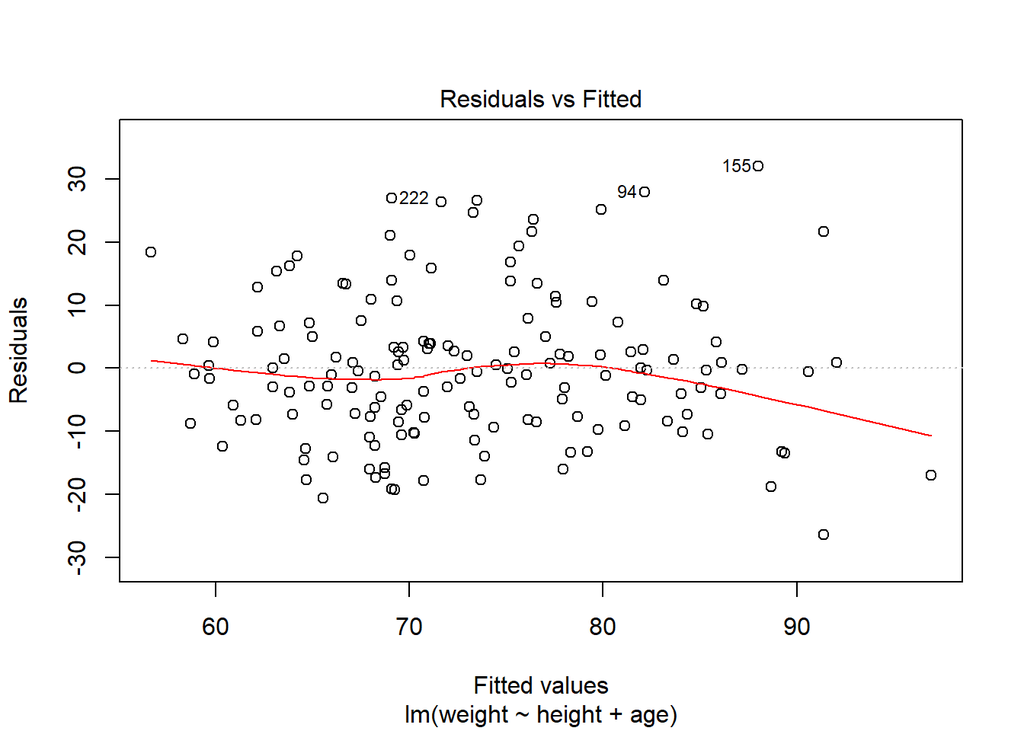

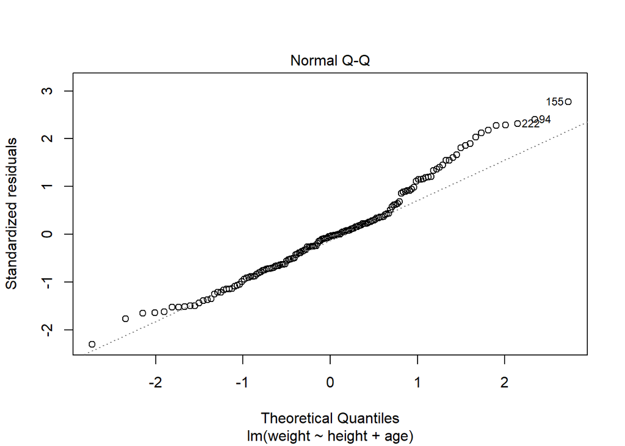

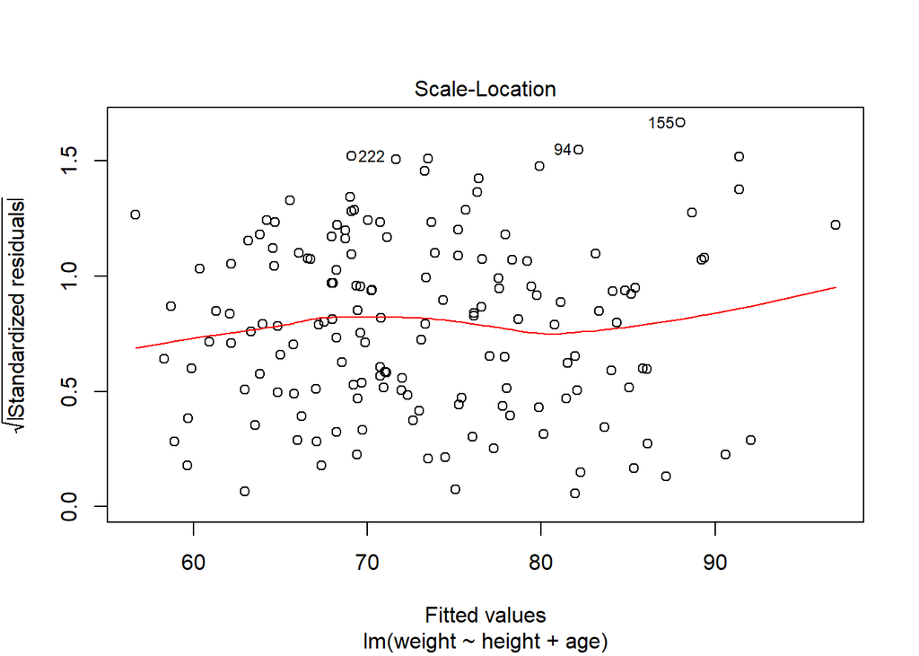

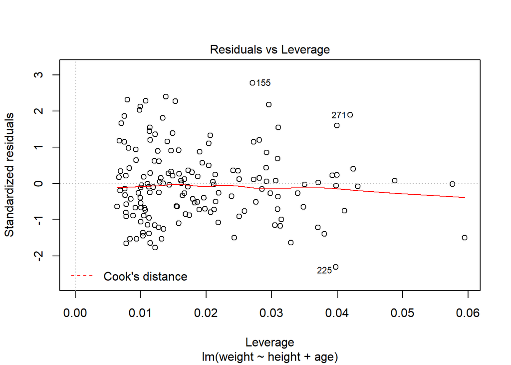

```r
plot(base_model_nooutlier)
```

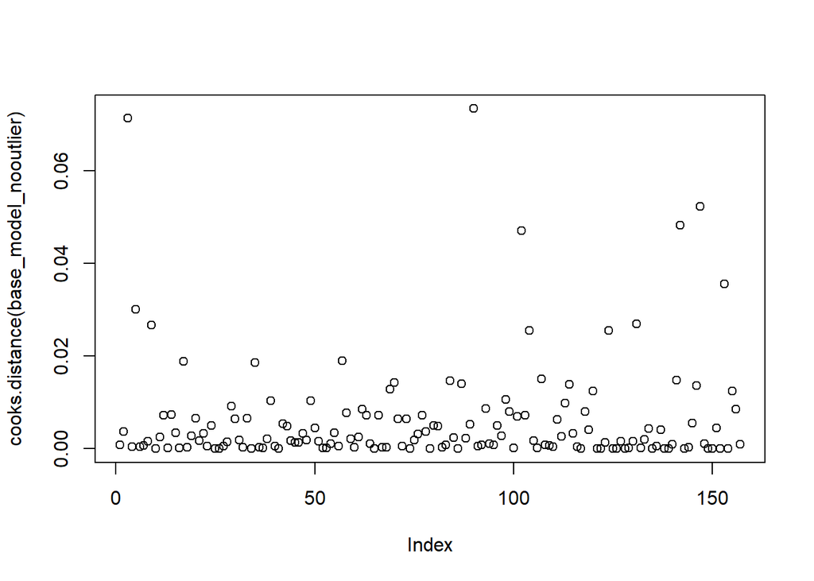

```r
plot(cooks.distance(base_model_nooutlier))
```

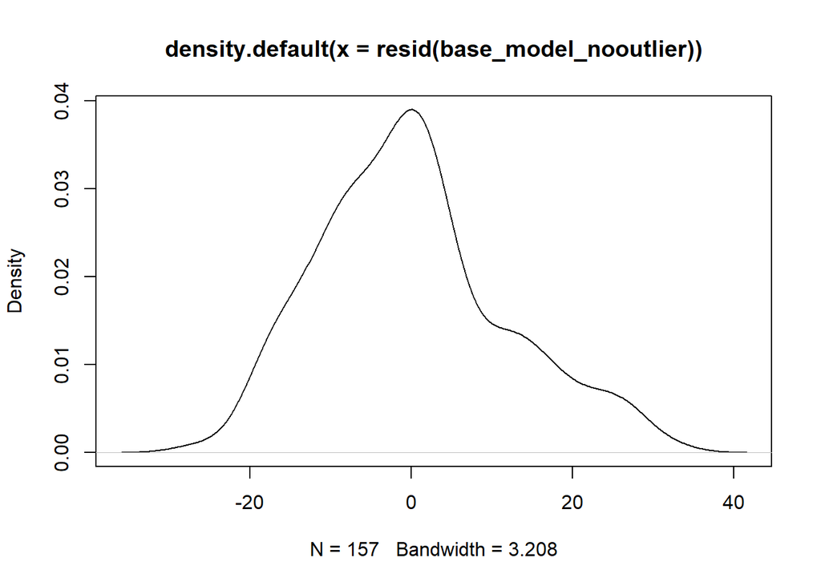

```r
plot(density(resid(base_model_nooutlier)))
```

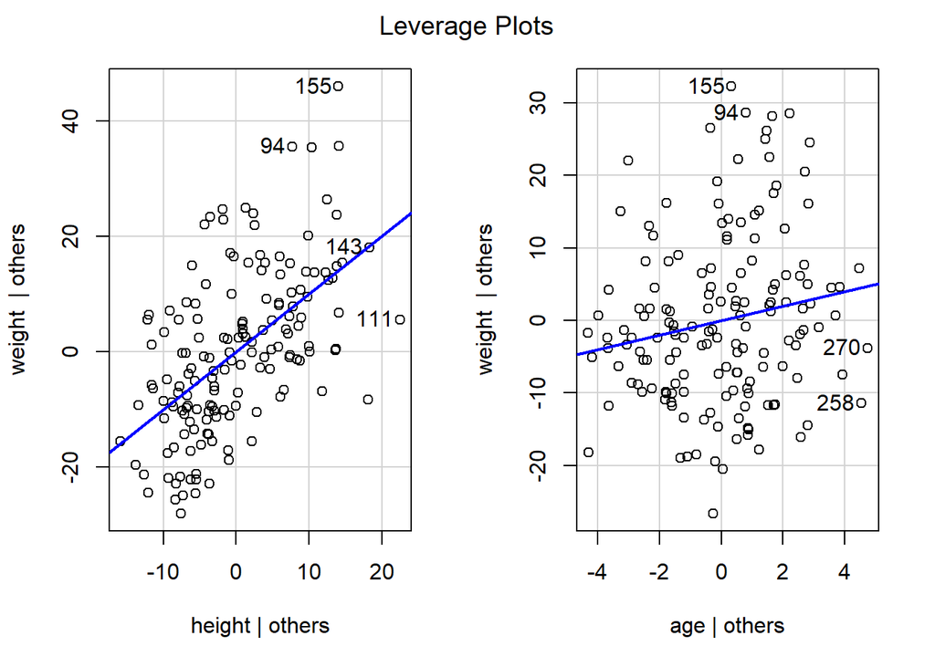

```r
leveragePlots(base_model_nooutlier)
```

```r
# vif
vif(base_model_nooutlier)
```

```
##   height      age
## 1.005639 1.005639
```